# Fakultät für Physik

## Physikalisches Praktikum P2 für Studierende der Physik

Versuch P2-23, 24, 25 (Stand: April 2023)

[Raum F1-16](http://www-ekp.physik.uni-karlsruhe.de/~simonis/praktikum/layoutobjekte/Lageplan_P1.png)

Name: Schwarz Vorname: Felix E-Mail: unuhz@student.kit.edu

\begin{equation*} \begin{split} &\\ &\\ \end{split} \end{equation*}

Name: Steib Vorname: Lukas E-Mail: uzmpb@student.kit.edu

\begin{equation*} \begin{split} &\\ &\\ &\\ \end{split} \end{equation*}

Gruppennummer: Mo-21

\begin{equation*} \begin{split} &\\ &\\ &\\ \end{split} \end{equation*}

Betreuer: Sebastian Koch

\begin{equation*} \begin{split} &\\ &\\ &\\ \end{split} \end{equation*}

Versuch durchgeführt am: 26.06.2023

**Beanstandungen:**

\begin{equation*} \begin{split} &\\ &\\ &\\ &\\ &\\ &\\ &\\ &\\ &\\ &\\ \end{split} %\text{\vspace{10cm}} \end{equation*}

Testiert am: __________________ Vermerk: __________________

# Laser-Optik, Teil B

## Motivation

Im Versuch [Laser-Optik, Teil A](https://git.scc.kit.edu/etp-lehre/p2-for-students/-/tree/main/Laser-Optik_Teil_A) haben Sie sich mit Hilfe einfacher Messungen mit den grundlegenden Eigenschaften und den Anwendungen von Lasern vertraut gemacht. In diesem Versuch können Sie Ihre experimentellen Erfahrungen um die Anwendung komplexerer interferometrischer Methoden zur Bestimmung kleinster Längenänderungen und um die Untersuchung der Eigenschaften doppelbrechender Kristalle mit Hilfe von linear polarisiertem Laserlicht erweitern. Den eigentlichen Versuchsteilen ist ein Demonstrationsversuch zur Veranschaulichung der Fourier-Transformation und ihrer Bedeutung in der Physik vorangestellt, der nahtlos an die Aufgaben des Versuchs "Laser-Optik, Teil A" anschließt. Beachten Sie hierzu die Hinweise zu diesem Versuch.

## Lernziele

Wir listen im Folgenden die wichtigsten **Lernziele** auf, die wir Ihnen mit dem Versuch **Laser-Optik, Teil B** vermitteln möchten:

- Sie untersuchen den Zusammenhang zwischen dem physikalischen Phänomen der Beugung, als Streuung von (kohärentem) Licht und der Fourier-Transformation, am Beispiel der Beugung am Einfachspalt. Dabei haben Sie die Möglichkeit eine vollautomatisierte Messanordnung genauer kennenzulernen.
- Sie untersuchen zwei Anwendungen für exakte interferometrische Messungen kleinster Längenänderungen. Dabei handelt es sich um die sehr kleinen [(magnetostriktiven) Längenänderung](https://de.wikipedia.org/wiki/Magnetostriktion) von Nickel und um die direkte Bestimmung der Wellenlänge des verwendeten Laserlichts selbst.
- Sie untersuchen den [Dopplereffekt von Licht](https://de.wikipedia.org/wiki/Doppler-Effekt#Longitudinaler_Doppler-Effekt), als intelligent durchdachte Anwendung des [Michelson-Interferometers](https://de.wikipedia.org/wiki/Michelson-Interferometer).
- Sie verwenden die Eigenschaft der linearen Polarisation des Laserlichts um den (Kristall im $\vec{B}$-Feld) [Faraday-](https://de.wikipedia.org/wiki/Faraday-Effekt) und (Kristall im $\vec{E}$-Feld) Pockels-Effekt zu studieren. Dabei bestimmen Sie verschiedene Materialkonstanten entsprechender [doppelbrechender Kristalle](https://de.wikipedia.org/wiki/Doppelbrechung).
- Sie untersuchen die [optische Aktivität](https://de.wikipedia.org/wiki/Optische_Aktivit%C3%A4t) von Zuckerlösungen. Auch hierzu verwenden Sie die Eigenschaft der linearen Polarisation des kohärenten Laserlichts.

## Versuchsaufbau

Auf einer optischen Bank können neben einem $\mathrm{He}$-$\mathrm{Ne}$-Laser die optischen Aufbauten für die durchzuführenden Versuche montiert werden. Die Versuche befinden sich in separaten Kabinen. Ein Beispielaufbau ist in der folgenden Photographie abgebildet: [Link]https://git.scc.kit.edu/etp-lehre/p2-for-students/-/raw/main/Laser-Optik_Teil_B/figures/LaserB.jpg

[figure not shown]

Für die verschiedenen Versuchsteile stehen Ihnen die folgenden Geräte und Materialien zur Verfügung:

- Ein Experimentiertisch (mit $3\,\mathrm{m}$-Zeißschiene) mit diversen Verschiebereitern.
- Ein $2\,\mathrm{mW}$-$\mathrm{He}$-$\mathrm{Ne}$-Laser mit $\lambda_{0}=632,8\,\mathrm{nm}$ Wellenlänge (in geschlossener Bauweise mit integriertem Netzteil, mit polarisiertem Licht).
- Ein Strahlaufweitungssystem (wie im Versuch Laser-Optik, Teil A), Justieraufbau mit Fassungen, Halter für Linsen und Blenden und ein großer weißer Schirm.
- Ein Multimeter (Voltcraft in verschiedenen Ausführungen).
- Ein Ampèremeter (Gossen Manometer, ohne Zusatzwiderstände $100\,\mathrm{mV}/1\,\mathrm{mA}$ (Vorsicht bei der Bedienung!), dazu Shunt)-Widerstände für $500\,\mathrm{mA}$ und für $5\,\mathrm{A}$ zur Messung der Spulenströme.
- Ein Funktionsgenerator FG 800/$0,2\,\mathrm{Hz}–200\,\mathrm{kHz}$.
- Ein Netzgerät für die Gleichspannung an der Pockelszelle, einstellbar bis $\approx1900\,\mathrm{V}$ mit integriertem Modulationstransformator.
- Jeweils ein Nieder (NF)- und Audiofrequenz(AF)-Verstärker.
- Ein Stromversorgungsgerät/Labor-Netzgerät (stufenlos und kurzzeitig bis zu $4\,\mathrm{A}$ einstellbar).
- Ein Glan-Thompson Polarisationsfilter; Durchmesser $d=10\,\mathrm{mm}$, auf einem Stift drehbar montiert mit Winkelskala ([Extinktionsverhältnis](https://de.wikipedia.org/wiki/Extinktionsverh%C3%A4ltnis): $10^{5}/1$). **Diesen Filter dürfen Sie nicht im unaufgeweiteten Strahl benutzen!**
- In $25\,\mathrm{mm}$-Fassungen:
  - Ein Polarisationsfilter ohne Skala (nicht an allen Plätzen verfügbar),
  - Ein Spalt der Breite $b=0,4\,\mathrm{mm}$,
  - Eine Lochblende mit Durchmesser $d=1\,\mathrm{mm}$ (nicht an allen Plätzen verfügbar),
  - Eine Irisblende,
  - Ein Achromat mit Brennweite $f=10\,\mathrm{mm}$,
  - Sammellinsen mit Brennweiten $f=30\,\mathrm{mm}$, $60\,\mathrm{mm}$ und $150\,\mathrm{mm}$ (die Linse mit $f=60\,\mathrm{mm}$ ist nicht an allen Plätzen verfügbar),
  - Tischlampe, Taschenlampe, 2 Laserschutzbrillen (nicht vollständigan allen Plätzen verfügbar).
- Im Schrank:
  - Lichtdetektor Si-Photoelement BPW34 (kleinflächig), $2,7\,\mathrm{mm}\times2,7\,\mathrm{mm}$, nur im Elementbetrieb, d.h. ohne Betriebsspannung direkt an Spannungs- oder Strommessgerät angeschlossen, zu verwenden. Der Anschluss erfolgt an den mit "+" und "-" bezeichneten Stiften mit jeweils spezieller Leitung (einfach vorhanden).
  - Lichtdetektor Si-Photoelement, Durchmesser $d=12\,\mathrm{mm}$, wie bei Versuchsteil A (einfach vorhanden).
  - Lichtdetektor für moduliertes Licht (mit Photoelement $2,7\,\mathrm{mm}\times2,7\,\mathrm{mm}$, NF-Verstärker und Lautsprecher).
  - Ein Michelson-Interferometer mit Feinverstellung eines Spiegels durch $(10:1)$-Hebeluntersetzung und Mikrometerschraube, eine dazu aufsteckbare Antriebsrolle für Motorantrieb (drei mal vorhanden).
  - Ein Michelson-Interferometer, ein Spiegel auf einem $\mathrm{Ni}$- bzw. $\mathrm{Fe}$-Stab befestigt, Länge $\ell=105\,\mathrm{mm}$, in einer Spule mit $n=2000$ Windungen (jeweils einmal vorhanden).
  - Ein Synchronmotor ($1\,\mathrm{U/min}$, mit Antriebsrolle und Gummiriemen für die Bewegung des Interferometerspiegels).
  - Eine Küvette ($198\,\mathrm{mm}\times58\,\mathrm{mm}$), in einem Halter auf einem Stift, für optisch aktive Lösungen (zweimal in Plastik- und einmal in Glasausführung).
  - Haushaltszucker in zwei Gefäßen.
  - Eine Chemikalienwaage, $1\times$ Mettler H 315 auf einem Wägetisch und drei verschiedene mechanische Waagen.
  - Bechergläser, Messzylinder, Trichter.
  - Sorbose-Lösung (optisch aktiv, linksdrehend, Massenkonzentration $\beta=0,33\,\mathrm{g\,cm^{-3}}$).
  - Faraday-Modulator, Bleisilikatglas der Länge $\ell=75\,\mathrm{mm}$ in einer Spule mit $n=800$ Windungen.
  - Ein Radioapparat mit Zweitlautsprecherausgang und zugehöriger Anschlussleitung, als Modulationsquelle.
  - Ein Lichtdetektor für moduliertes Licht (mit Photoelement $2,7\,\mathrm{mm}\times2,7\,\mathrm{mm}$, NF-Verstärker und Lautsprecher).
  - Pockelszelle im Drehhalter mit Skala zur Angabe des Winkels zwischen Feld- und Laserpolarisationsrichtung, Lithiumniobat-Kristall, Höhe $h=2\,\mathrm{mm}$ (entspricht dem Elektrodenabstand), Länge $\ell=20\,\mathrm{mm}$, optische Achse parallel zur Feldrichtung.
  - Stimmgabel $1700\,\mathrm{Hz}$ ($2\times$), Maßband ($1\times$) , Stoppuhr ($5\times$).
  - Aufbau für die optische Bank mit Fototransistor, Schrittmotor und Endschaltern.
  - Vorverstärker, Schrittmotor- und Relais-Schnittstelle.
  - 2 Laserschutzbrillen (für das Betreuungspersonal).
  - Rechner (IBM-kompatibler PC 386SX) mit VGA-Graphikkarte, Graphik-Drucker, Maus, Festplatte, $1,2\,\mathrm{MB}$ und $1,44\,\mathrm{MB}$-Laufwerk und spezieller Schnittstellen-Karte (ADC, DAC, PIO), (nur einmal vorhanden).

## Wichtige Hinweise

- Bei diesem Versuch arbeiten Sie mit einem Laser, der entsprechend **gefährlich für Ihre Augen** sein kann. Gehen Sie daher **vorsichtig und verantwortungsbewusst** mit dem Laser um und halten Sie sich an die Anweisungen des/der Tutor:in.
- Achten Sie darauf, dass alle Personen im Raum bei der Durchführung des Versuchs eine **Schutzbrille** tragen.
- Vermeiden Sie direkten Blickkontakt mit dem Laserstrahl und richten Sie ihn niemals auf andere Personen. Bleiben Sie beim Experimentieren in der Regel stehen, mit den Augen also weit oberhalb der Strahlhöhe.
- Stellen Sie sicher, dass die Laserleistung und -frequenz auf die vorgesehenen Werte eingestellt sind und überprüfen Sie dies regelmäßig während des Experiments.
- Beachten Sie, dass der Laserstrahl bei falscher Handhabung Schäden an optischen Elementen verursachen kann. Verwenden Sie nur die bereitgestellten optischen Elemente und reinigen Sie sie nur mit geeigneten Materialien.
- Vor dem Einschalten des Lasers müssen alle Geräte sorgfältig aufgebaut und justiert werden. Führen Sie diese Schritte **erst nach Rücksprache mit dem/der Tutor:in** durch.

## Durchführung

### **Aufgabe 1: Beugungsbild eines Spalts**

Hierbei handelt es sich um einen **Demonstrationsversuch**. Er soll von allen Gruppen gemeinsam und mit Unterstützung des Betreuers durchgeführt werden. Mithilfe eines auf einen Schrittmotor montierten Phototransistors messen Sie das Beugungsbild eines Spalts aus, der mit einem $\mathrm{He}$-$\mathrm{Ne}$-Laser ausgeleuchtet wird. Die gewonnenen Daten werden auf einem bereitstehenden Computer verarbeitet; aus der [Fourier-Rücktransformation](https://de.wikipedia.org/wiki/Fourier-Transformation) des aufgezeichneten Beugungsbildes erhalten Sie das Bild des Spalts. Dokumentieren und diskutieren Sie Ihre Beobachtungen.

**Lösung:**  
Um das Beugungsbild des Einzelspalts zu messen wird der Schirm in einem festen Abstand $l$ zum Einzelspalt positioniert. Die Strecke $l$ wird in ein Computerprogramm gegeben. Ein Phototransistor auf einem Schrittmotor misst das Beugungsbild.  
Mit dem Computerprogramm wird mithilfe einer fast-fourier-transformation (fft) die Breite des Einzelspalts bestimmt.  
Es ergibt sich folgendes Bild für den Spalt:

[figure not shown]

Die experimentell bestimmte Spaltbreite beträgt $0.432 mm$. Auf dem verwendeten Einzelspalt ist eine Spaltbreite von $ 0.4 mm$ angegeben.  
Der experimentelle und der theoretische Wert für den Einzelspalt passen nicht genau überein. Dies kann an einer falschen Kalibration des Phototransistors mit Computerprogramm liegen.

### **Aufgabe 2: Anwendungen des [Michelson-Interferometers](https://en.wikipedia.org/wiki/Michelson_interferometer)**

**2.1:** Beobachten Sie interferometrisch die sehr geringe Abhängigkeit der Länge von Nickel vom Magnetfeld $\vec{H}$ und bestimmen Sie den [Magnetostriktionskoeffizienten](https://de.wikipedia.org/wiki/Magnetostriktion).

**2.2:** Bestimmen Sie aus den beobachteten Änderungen des Interferenzbildes bei gemessener Verschiebung eines der Spiegel die Wellenlänge des Laserlichts.

**2.3:** Demonstrieren Sie den "[Dopplereffekt](https://de.wikipedia.org/wiki/Doppler-Effekt#Longitudinaler_Doppler-Effekt)" mit Lichtwellen im Fall $v\ll c$ und messen Sie $v$ interferometrisch.

**2.4:** Bewegen Sie eine schwingende Stimmgabel von Ihrem Ohr weg und auf Ihr Ohr zu und zwar einmal mit und einmal ohne eine reflektierende Wand in der Nähe (akustisches Analogon zu Aufgabe 2.3). Dokumentieren und disutieren Sie Ihre Beobachtungen.

**Lösung:**  
Das Michelson-Interferometer besteht aus einem halbdurchlässigen Spiegel und zwei voll reflektierenden Spiegeln. Der halbdurchlässige Spiegel teilt einen Lichtstrahl in zwei Wege auf, die reflektiert und überlagert werden. Durch die Interferenz der Teilstrahlen entsteht ein Interferenzmuster. Ein Spiegel ist in seiner Position variabel. Mit verschieben des Spiegels folgt eine Änderung des Interferenzmusters.  
Aufbau Michelson-Interferometer:

[figure not shown]

https://upload.wikimedia.org/wikipedia/commons/3/32/Michelson-Morley.svg
**2.1:**
Der benutzte Laser ($632.8 nm$) hat kein diskretes Spektrum, sondern es ist gaußverteilt. Deshalb wird eine Standardabweichung von $0.1 nm$ angenommen.
Magnetostriktion findet bei Ferromagneten in einem Magnetfeld statt. Dabei vollführt der Ferromagnet eine Längenänderung. Dies ist auf eine gleichausrichtung der Weißschen Bezirke zurückzuführen. Es wird bei diesem Versuchsteil wird ein Stück Nickel umgeben von einer Spule an dem beweglichen Spiegel befestigt. Dann kann die Längenänderung des Nickels $\Delta l$ und der Magnetostriktionskoeffizient $c_{Ni}$ bestimmt werden, indem die Interferenz beobachtet wird.
Die Längenänderung ist mit der Formel $\Delta l = c_{Ni} \cdot l \cdot H $ bestimmen. Als Magnetfeld lässt sich das Magnetfeld einer langen Spule verwenden mit $H = \frac{N \cdot I}{l}$. Dabei ist N die Wicklungszahl der Spule.
Damit folgt für den Magnetostriktionskoeffizient $c_{Ni}$:
$$ c_{Ni}= \frac{m \cdot \lambda}{2 N \cdot I} $$ m ist die Ordnung des gemessenen Minimums. Es wird ein Stab mit $l = 0.105 m$ verwendet. Die Wicklungszahl beträgt 2000. Es wird ein Laser mit Wellenlänge $\lambda = 632,8 nm$ verwendet.
Mit einem linearen Fit wird $c_{Ni}$ bestimmt. Beim Messen der Stromstärke wird eine Unsicherheit von $60 mA$ angenommen. Die Unsicherheit wird so groß angenommen, da es während dem Versuch sich die Spule aufgeheitzt hat und somit das System nicht statisch gewesen sein kann.

```python
import numpy as np
import matplotlib.pyplot as plt
from PhyPraKit import readPicoScope, resample
from scipy import signal
from scipy import interpolate
import sys
from kafe2 import  XYContainer, Fit, XYFit, Plot, ContoursProfiler
from uncertainties import ufloat, unumpy
from math import log10, floor
import scipy.integrate as integrate
import pandas as pd
import csv
```

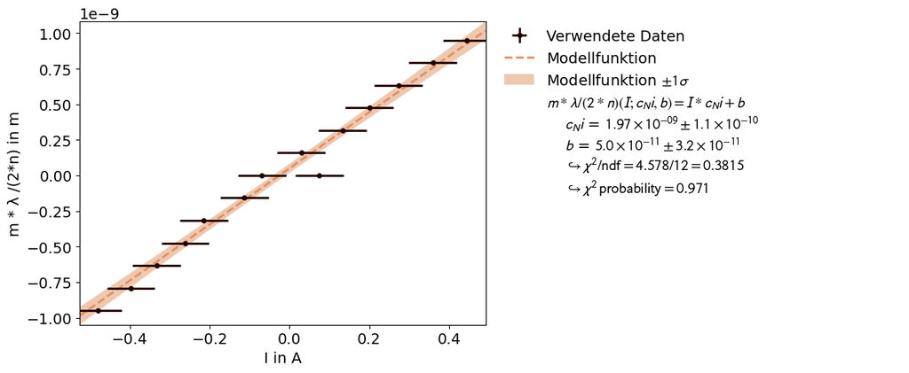

```python
l=ufloat(0.105,0.01) # in m
n=2000
lamda=ufloat(632.8*10**(-9),0.1*10**(-9)) # in m
m = np.array([-6,-5,-4,-3,-2,-1,0,0,1,2,3,4,5,6])
I = unumpy.uarray(np.array([ -0.48,-0.398,-0.333,-0.262,-0.215,-0.113,-0.069,0.075,0.029,0.133,0.200,0.273,0.359,0.445]),np.array([np.full(14,0.06)]))

y=m*lamda/(2*n)
z = I[0]
xy_data = XYContainer(unumpy.nominal_values(z),unumpy.nominal_values(y))
y_error = unumpy.std_devs(y)
z_error = unumpy.std_devs(z)
def linear(x,a=0.0000021,b=0):
    return x*a+b
line_fit=Fit(data=xy_data,model_function=linear)
line_fit.add_error(axis='x', err_val=z_error,relative=False)  # add the x-error to the fit
line_fit.add_error(axis='y', err_val=y_error,relative=False)

line_fit.do_fit()
line_fit.assign_parameter_latex_names(x='I', a='c_Ni',b='b')
line_fit.assign_model_function_latex_name('m * λ /(2*n)')
line_fit.assign_model_function_latex_expression(' {x} *  {a} + {b}')

line_fit.data_container.label = "Verwendete Daten"
line_fit.model_label = "Modellfunktion"

line_fit.data_container.axis_labels = ['I in A','m * λ /(2*n) in m']
plot = Plot(fit_objects= line_fit)

plot.plot()
plt.show()
```

Damit ergibt sich ein Magnetostriktionskoeffizient $c_{Ni}$ von $1.97 \pm 0.11 \frac{nm}{A}$.  
In dem linearen Fit ist ein Ausreiser erkennbar. Dies kann an einem falschen Ablesen des gemessenen Werts liegen.  
Der Magnetostriktionskoeffizient ist sehr klein (Nanometerbereich).  
Es wurde kein Literaturwert gefunden um den gemessenen Wert des Magnetostriktionskoeffizient des Nickelstabs mit dem Literaturwert zu vergleichen.  
Bei dem Versuchsteil wird nicht die Ausdehnung der Stabs mit steigendem Strom berücksichtigt.

**2.2:**  
Der bewegliche Spiegel befindet sich auf einem Mikrometerschlitten. Mit einer Stellschraube lässt sich die Position des Schlittens verändern. Es wird die Strecke $\Delta l$ gemessen, die durchlaufen wird, wenn verschiedene Minima auftreten.  
Es werden immer für 5 Minima $j$ gemessen, da die Längenänderung sehr gering ist.  
Anschließend lässt sich mit $\lambda = \frac{2 \cdot \Delta l}{j}$ die Wellenlänge des Lasers bestimmen.  
Dazu wird auch wieder ein linearer Fit verwendet.

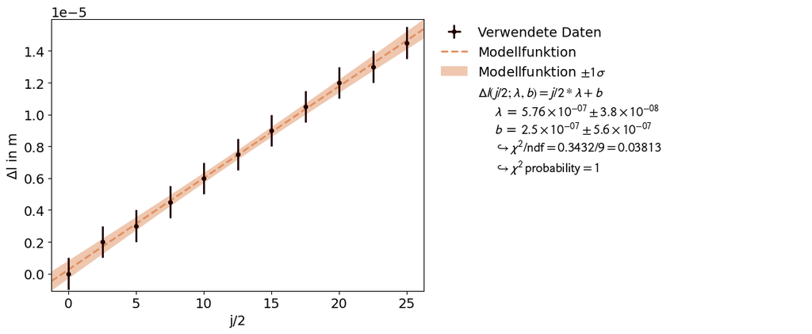

```python
delta_l_true=np.array([14.4,14.38,14.37,14.355,14.34,14.325,14.31,14.295,14.28,14.27,14.255])*10**(-4)
delta_l_std=np.full(11,0.01)*10**(-4)
delta_l=unumpy.uarray(delta_l_true,delta_l_std) # in mm
delta_l =  abs(delta_l-(14.4*10**(-4)))
j=np.array([0,5,10,15,20,25,30,35,40,45,50])



xy_data = XYContainer(j/2,unumpy.nominal_values(delta_l))
y_error = unumpy.std_devs(delta_l)
def linear(x,a=0.000000632,b=0):
    return x*a+b
line_fit=Fit(data=xy_data,model_function=linear)
#line_fit.add_error(axis='x', err_val=x_error,relative=False)  # add the x-error to the fit
line_fit.add_error(axis='y', err_val=y_error,relative=False)

line_fit.do_fit()
line_fit.assign_parameter_latex_names(x='j/2', a='\lambda',b='b')
line_fit.assign_model_function_latex_name('Δl')
line_fit.assign_model_function_latex_expression(' {x} *  {a} + {b}')

line_fit.data_container.label = "Verwendete Daten"
line_fit.model_label = "Modellfunktion"

line_fit.data_container.axis_labels = ['j/2','Δl in m']
plot = Plot(fit_objects= line_fit)

plot.plot()
plt.show()
```

Somit ergibt sich ein experimentell bestimmter Wert für die Wellenlänge des Lasers von $\lambda = 576 \pm 38 nm$.  
Die bekannte Wellenlänge des Lasers beträgt $632,8 nm$.  
Der experimentelle und der bekannte Wert passen nicht überein. Dies kann an dem schwierigen Einstellen der Minima liegen. Sobald die Stellschraube auch schon berührt wird ändern sich die Minima. Es ist auch möglich das die Skala auf der Stellschraube nicht genau geeicht war oder einwandfrei in einem anderen Temperaturbereich einsatzfähig ist.

**2.3:**  
Es wird ein Spiegel mit einem Motor gedreht. Es wird immer gemessen, wie lange es braucht bis eine gewisse Anzahl an Maxima (m) durchlaufen wurden ist. Damit lässt sich die Spiegelgeschwindigkeit ermitteln,  
$ v= \frac{\Delta \nu \cdot c}{2 \cdot f_{Sender}} = \frac{m \cdot c}{2 \cdot t \cdot f_{Sender}} =\frac{m \cdot \lambda}{2 \cdot t}$. Die Formel wird umgestellt zu $t=\frac{m \cdot \lambda}{2} \cdot v$. Anschließend wird mit einem einem linearen Fit die Geschwindigkeit $v$ bestimmt.\ Es wird für die Zeit eine Unsicherheit von $2 s$ angenommen, da zwischen ablesen der Zeit und Werte gemessene Werte durchgeben einiges an Zeit vergehen kann. Die Geschwindigkeit ist auch anders berechenbar, mit der Formel $v=\frac{\Delta l}{t}$. Dazu wird nach 5 Sekunden immer die zurückgelegte Strecke gemessen.

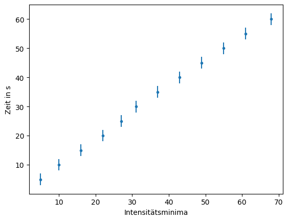

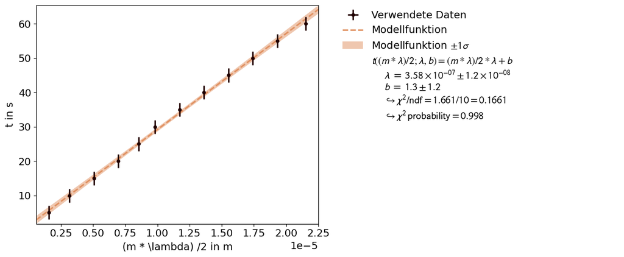

```
anders: 5.7273e-06 +- 7.629e-07
```

```python
l_true=np.array([0.05,0.114,0.173,0.24,0.287,0.35,0.4,0.47,0.52,0.575,0.632,0.68])*10**-4
l_std=np.full(12,(0.001*10**(-4)))
l = unumpy.uarray(l_true,l_std)
t = unumpy.uarray(np.array([5,10,15,20,25,30,35,40,45,50,55,60]),np.full(12,2))
delta_l=np.zeros(11)
delta_t=np.zeros(11)
v_rech=np.zeros(11)
for i in range(11):
    delta_l[i]=(unumpy.nominal_values(l[i+1])-unumpy.nominal_values(l[i]))
    delta_t[i]=(unumpy.nominal_values(t[i+1])-unumpy.nominal_values(t[i]))
    v_rech[i]=delta_l[i]/delta_t[i]
lamda=ufloat(632.8*10**(-9),0.01*10**(-9)) # in m
m=np.array([5,10,16,22,27,31,37,43,49,55,61,68])

plt.errorbar(m,unumpy.nominal_values(t),unumpy.std_devs(t), marker='.',linestyle='None')
plt.xlabel('Intensitätsminima')
plt.ylabel('Zeit in s')
plt.show()

#v=m*lamda/(2*t)
hilfsgroesse4=1/(2/(m*lamda))
xy_data = XYContainer(unumpy.nominal_values(hilfsgroesse4),unumpy.nominal_values(t))
y_error = unumpy.std_devs(t)
x_error = unumpy.std_devs(hilfsgroesse4)
def linear(x,a=0.000000632,b=0):
    return x/a+b
line_fit=Fit(data=xy_data,model_function=linear)
line_fit.add_error(axis='x', err_val=x_error,relative=False)  # add the x-error to the fit
line_fit.add_error(axis='y', err_val=y_error, relative=False)

line_fit.do_fit()
line_fit.assign_parameter_latex_names(x='(m * \lambda) /2 ', a=' \lambda',b='b')
line_fit.assign_model_function_latex_name('t')
line_fit.assign_model_function_latex_expression(' {x} *  {a} + {b}')

line_fit.data_container.label = "Verwendete Daten"
line_fit.model_label = "Modellfunktion"

line_fit.data_container.axis_labels = ['(m * \lambda) /2 in m','t in s']
plot = Plot(fit_objects= line_fit)

plot.plot()
plt.show()




#print ('Der Spiegel hat eine Geschwindigkeit von',np.round(np.mean(unumpy.nominal_values(v)),10),'+/-',np.round(np.std(unumpy.nominal_values(v)),10))
print('anders:',np.round(np.mean(delta_l),10),'+-',np.round(np.std(delta_l),10))
```

Mit dem Fit ist eine Spiegelgeschwindigkeit von $3.58 \cdot 10^{-7} \pm 1.2 \cdot 10^{-8} \frac{m}{s}$ messbar.  
Mit der Formel für die gleichförmige Bewegung ergibt sich eine Spiegelgeschwindigkeit von $1.146 \cdot 10^{-6} \pm 1.526 \cdot 10^{-7} \frac{m}{s}$.  
Die beiden Geschwindigkeiten sollten die gleichen sein, passen aber nicht übereinander. Dies kann am schwierigen Ablesen der Werte während der Versuchsdurchführung liegen. Auch ist es möglich, dass es nicht immer nach genau 5 Sekunden abgelesen wurde.

**2.4:**  
Bei dem akustischen Dopplereffekt wird eine in Schwingung versetzte Stimmgabel auf den Experimentator zu bzw. von ihm weg bewegt. Es sind unterschiedlich hohe Töne dabei hörbar, die hörbare Frequenz ist bei hin- und wegbewegen eine andere.  
Desweiteren wird die Stimmgabel an eine Wand und von ihr weg gebracht. Die Wand dient als Spiegel, der die Schallwellen wieder zurück wirft. Es kommt zu einer Schwebung.

### **Aufgabe 3: Faraday- und Pockels-Effekt**

**3.1:** Modulieren Sie die Intensität des Laserlichts durch Anwendung des [Faraday-Effekts](https://de.wikipedia.org/wiki/Faraday-Effekt), indem Sie das linear polarisierte Laserlicht erst einen Stab aus Bleisilikatglas im longitudinalen Magnetfeld einer Spule und dann einen Polarisationsfilter durchlaufen lassen.

**Lösung**

In diesem Versuchsteil leiten wir linear polarisiertes Licht in einen Stab aus Bleisilikatglas, welcher von einer Spule umgeben ist. Das Magnetfeld der Spule verändert nun den Drehwinkel des eingestrahlten Lichts. In unserem Fall steuern wir die Spule mit einem verstärktem Audiosignal an, wodurch die Informationen des Audiosignals auf das Laserlicht übertragen werden. Das modulierte Licht durchläuft einen Polarisationsfilter zur Intensitätseinstellung und lässt sich dann an einer Photodiode in Strom umwandeln, welche einen Lautsprecher ansteuert, um das Audiosignal auszugeben. Das Audiosignal wird hierbei etwas verzerrt, da die hohen Frequenzen zum Beispiel durch die Abtastrate der Photodiode, aber auch der Trägheit der Induktivität nicht richtig übertragen werden.

**3.2:** Bestimmen Sie die Verdet-Konstante

\begin{equation*} V \equiv \frac{\alpha}{B\,l} \end{equation*}

von Bleisilikatglas, wobei $B$ der Magnetfeldstärke und $l$ der Länge des Stabs entsprechen und $\alpha$ der Winkel ist, um den das linear polarisierte Licht beim Durchlaufen des Stabs gedreht wurde.

**Lösung**

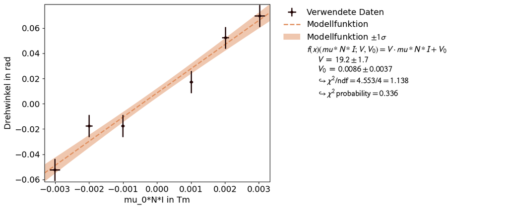

```python
drehwinkel = np.array([-3,-1,-1,1,3,4])
drehwinkel2 = drehwinkel*2*np.pi/360 # in rad
drehwinkel2_std = 0.5*2*np.pi/360 # in rad
strom = np.array([-3,-2,-1,1,2,3])
mu = 1
l = 0.075
mu_0 = 4*np.pi*10**(-7)
N = 800
#V = drehwinkel/(mu*mu_0*N*strom)
x = (mu*mu_0*N*strom)
y = drehwinkel2
xy_data = XYContainer(x,y)
def linear(x,a=14,b=0):
    return a*x+b
line_fit=Fit(data=xy_data,model_function=linear)
line_fit.add_error(axis='x', err_val=0.05,relative=True)
line_fit.add_error(axis='y', err_val=drehwinkel2_std,relative=False)
line_fit.do_fit()
line_fit.assign_parameter_latex_names(x='mu*N*I', a='V',b='V_0')
line_fit.assign_model_function_latex_name('f(x)')
line_fit.assign_model_function_latex_expression('{a} \\cdot {x} + {b}')


line_fit.data_container.label = "Verwendete Daten"
line_fit.model_label = "Modellfunktion"

line_fit.data_container.axis_labels = ["mu_0*N*I in Tm","Drehwinkel in rad"]
plot = Plot(fit_objects= line_fit)
plot.plot()
plt.show()
```

**3.3:** Modulieren Sie die Intensität des Laserlichts durch Anwendung des [Pockels-Effekts](https://de.wikipedia.org/wiki/Pockels-Effekt), indem Sie das linear polarisierte Laserlicht einen Lithiumniobat-Kristall mit transversalem elektrischen Feld (Feldrichtung $45°$ gegen die Polarisationsrichtung des Laserlichts gedreht) und ein Polarisationsfilter ($90°$ gegen die Polarisationsrichtung des Laserlichts gedreht) durchlaufen lassen.

**Lösung:**

In diesem Aufgabenteil haben wir den gleichen Aufbau wie in Aufgabe 3.1, nur mir einer Pockelszelle statt einer Spule und Bleisilikatglas. Die Pockelszelle wird durch ein verstärktes Audiosignal angesteuert, wodurch die Audioinformationen auf den Drehwinkel des Laserlichts übertragen werden. Das Laserlichts durchläuft wieder einen Polarisationsfilter und wird dann durch eine Photodiode in Strom umgewandelt, welche einen Lautsprecher ansteuert. Anders als beim Faradayeffekt sind die höheren Frequenzen hier besser hörbar, da das elektrische Feld der Pokelszelle schneller auf hohe Frequenzen reagieren kann als eine Spule. Dennoch ist wie im beim Faradayeffekt ein deutliches Rauschen zu hören, was unter anderem an dem Umgebungslicht liegen kann, welches die Photodiode erreicht.

**3.4:** Bestimmen Sie die Konstante

\begin{equation*} k \equiv \frac{\Delta n(E)}{E} \end{equation*}

für den Pockels-Effekt bei Lithiumniobat für die Wellenlänge des Laserlichts, wobei $\Delta n(E)$ der Änderung des Brechungsindex und $E$ der elektrischen Feldstärke entsprechen.

**Lösung:**  
Wir betrachten das durch die Pockelszelle beeinflusste Laserlicht auf einem Schirm. Dort ist eine Hyperbelfigur sichtbar. Wir varieren die Spannung von -1900V bis 1900V und schreiben uns die Spannungen auf, bei der ein Extrema in der Mitte der Hyperbelfigur auftritt.

Wir berechnen $k = \Delta n /E $  
durch  
$\phi = \frac{k\cdot E \cdot s}{\lambda_0} = \frac{k\cdot U \cdot s}{d \cdot\lambda_0}$  
folgt  
$k = \frac{\lambda_0 \cdot d}{2 \cdot s \cdot U_{HW}}$.  
Dabei ist $U_{HW}$ die Halbwellenspannung, welche wir aus einem Fit der Spannung über die Extremanummer erhalten. Dabei nehmen wir eine systematischen Unsicherheit von 50V für die Spannung an, um Messunsicherheiten zu beachten.

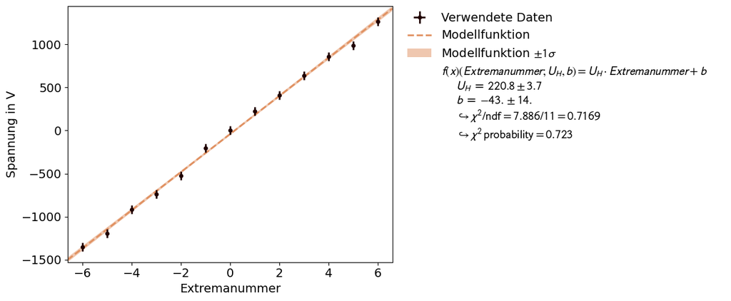

```
(1.433+/-0.024)e-10
```

```python
extremanummer = np.array([6,5,4,3,2,1,0,-1,-2,-3,-4,-5,-6])
U = np.array([1267,986,861,639,406,222,1,-204,-526,-738,-920,-1197,-1353 ])

xy_data = XYContainer(extremanummer,U)
def linear(x,a=0,b=0):
    return a*x + b
line_fit=Fit(data=xy_data,model_function=linear)
line_fit.add_error(axis='y', err_val=50,relative=False)
line_fit.do_fit()
line_fit.assign_parameter_latex_names(x='Extremanummer', a='U_H')
line_fit.assign_model_function_latex_name('f(x)')
line_fit.assign_model_function_latex_expression('{a} \\cdot {x} + {b}')


line_fit.data_container.label = "Verwendete Daten"
line_fit.model_label = "Modellfunktion"

line_fit.data_container.axis_labels = ["Extremanummer", "Spannung in V"]
plot = Plot(fit_objects= line_fit)
plot.plot()
plt.show()

U_HW = ufloat(220.8,3.7)
lamda_0 = 632.8 * 10**(-9)
d = 2 * 10**(-3)
s = 20 * 10**(-3)
k = lamda_0 * d / (2 * s * U_HW)
print(k)
```

Durch unseren Fit erhalten wir eine Halbwellenspannung von $U_{HW} = 220.8 \pm 3.7$. Die hohe xi^2 Wahrscheinlichkeit deutet auf eine gute Näherung an den wahren Wert hin. Mit diesem Wert für die Halbwellenspannung berechnen wir nur die Konstante k und erhalten $k = 1.433\cdot 10^{-10} \pm 0.024 \cdot 10^{-10}$ m/V . Dabei sind die Werte d = 2mm und s = 20 mm gegeben.  
Ein Literaturwert ist leider nicht erhältlich, wodurch ein Vergleich nicht möglich ist.

### **Aufgabe 4: [Optische Aktivität](https://de.wikipedia.org/wiki/Optische_Aktivit%C3%A4t) (Saccharimetrie)**

**4.1:** Bestimmen Sie den [spezifischen Drehwinkel](https://de.wikipedia.org/wiki/Optische_Aktivit%C3%A4t#Spezifischer_Drehwinkel)

\begin{equation*} \left[\alpha\right]_{\lambda}^{T} = \frac{\alpha}{\beta\,\ell} \end{equation*}

einer Haushaltszuckerlösung bei verschiedenen Massenkonzentrationen $\beta$ (gemessen in $\mathrm{g\,cm^{-3}}$) sowie die Drehrichtung. Dabei entsprechen $\alpha$ dem unspezifischen (gemessenen) Drehwinkel gemessen in $^{\circ}$ und $\ell$ der Länge des Lichtweges durch die Lösung (gemessen in $\mathrm{dm}$). Zeigen Sie, dass $\alpha\propto\ell$ und $\alpha\propto \beta$ gilt.

Zum Nachweis von $\alpha\propto\ell$ genügt es zwei Messwerte aufzunehmen bei denen die Küvette mit der Probelösung einmal längs und einmal quer durchstrahlt wird. Zum Nachweis von $\alpha\propto\beta$ beginnen Sie z.B. bei $\beta\approx 0,3\,\mathrm{g\,cm^{-3}}$ und reduzieren Sie die Konzentration, indem Sie Wasser zugießen. Diskutieren Sie von welchen weiteren Parametern $\alpha$ noch abhängt.

Wenn Sie die Konzentration ändern, während Sie den durchtretenden Laserstrahl beobachten, scheint dieser "krummen Bahnen" zu folgen. Beachten Sie Ähnlichkeiten zwischen der optischen Aktivität und dem Faraday-Effekt.

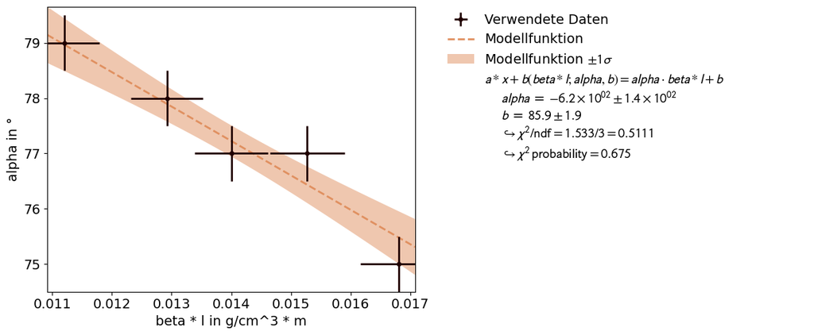

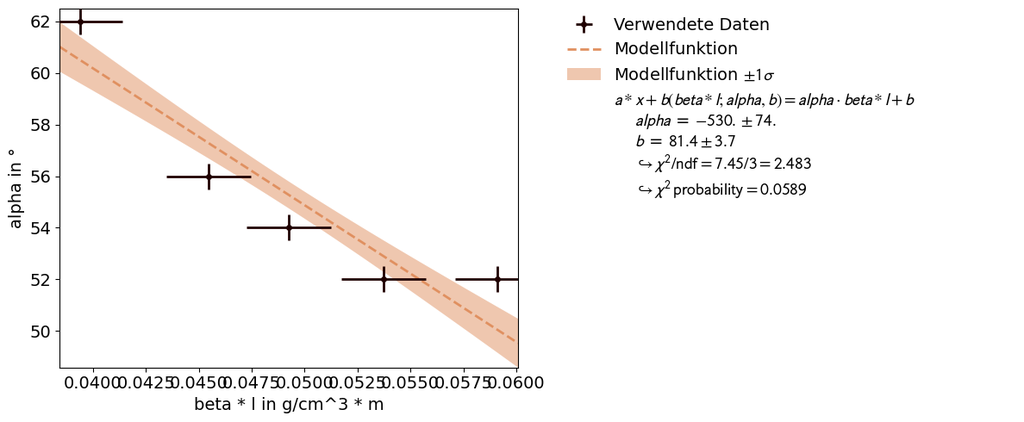

```
-561.1214953271028 +- 42.80639097196128
```

```python
# Nullmessung kein Wasser verschiebung um 80°
alpha1 = unumpy.uarray(np.array([75,77,77,78,79 ]),np.full(5,0.5))
beta1 = unumpy.uarray(np.array([150/500, 150/550,150/600,150/650,150/750]),np.full(5,0.01))
l1 = ufloat(0.056,0.001) # in m Breite
hilfsgroesse = beta1 * l1

xy_data = XYContainer(unumpy.nominal_values(hilfsgroesse),unumpy.nominal_values(alpha1))
def linear(x,a=0,b=0):
    return a*x + b
line_fit=Fit(data=xy_data,model_function=linear)
line_fit.add_error(axis='x', err_val=unumpy.std_devs(hilfsgroesse))
line_fit.add_error(axis='y', err_val=unumpy.std_devs(alpha1))
line_fit.do_fit()
line_fit.assign_parameter_latex_names(x='beta * l', a='alpha')
line_fit.assign_model_function_latex_name('a * x +b')
line_fit.assign_model_function_latex_expression('{a} \\cdot {x} + {b}')


line_fit.data_container.label = "Verwendete Daten"
line_fit.model_label = "Modellfunktion"

line_fit.data_container.axis_labels = ["beta * l in g/cm^3 * m", "alpha in °"]
plot = Plot(fit_objects= line_fit)
plot.plot()
plt.show()

alpha2 = unumpy.uarray(np.array([52,52,54,56,62]),np.full(5,0.5)) # in °
beta2 = unumpy.uarray(np.array([150/500,150/550,150/600,150/650,150/750]),np.full(5,0.01))
l2 = ufloat(0.197,0.001) # in m Länge
hilfsgroesse2 = beta2 * l2

xy_data = XYContainer(unumpy.nominal_values(hilfsgroesse2),unumpy.nominal_values(alpha2))
def linear(x,a=0,b=0):
    return a*x + b
line_fit=Fit(data=xy_data,model_function=linear)
line_fit.add_error(axis='x', err_val=unumpy.std_devs(hilfsgroesse2))
line_fit.add_error(axis='y', err_val=unumpy.std_devs(alpha2))
line_fit.do_fit()
line_fit.assign_parameter_latex_names(x='beta * l', a='alpha')
line_fit.assign_model_function_latex_name('a * x +b')
line_fit.assign_model_function_latex_expression('{a} \\cdot {x} + {b}')


line_fit.data_container.label = "Verwendete Daten"
line_fit.model_label = "Modellfunktion"

line_fit.data_container.axis_labels = ["beta * l in g/cm^3 * m", "alpha in °"]
plot = Plot(fit_objects= line_fit)
plot.plot()
plt.show()


a1 = ufloat(-620, 140)
a2 = ufloat(-530, 74)
weights = np.array([(1/140,1/74)])
values = np.array([-620,-530])
weighted_mean = (values * weights).sum() / weights.sum()

weighted_sigma = np.sqrt((np.sum(weights*values**2) / np.sum(weights))- weighted_mean**2)
print(weighted_mean,"+-",weighted_sigma)
```

Um dem wahren Wert des spezifischen Drehwinkel möglichst gut anzunähern, bilden wir den gewichteten Mittelwert aus den beiden ermittelten Werten. Somit ergibt sich dann für den spezifischen Drehwinkel $\alpha_{spez} = -561.1 \pm 42.8 \frac{1}{g/cm^3\cdot m}$. (Gewichteter Mittelwert implementiert nach http://seismo.berkeley.edu/~kirchner/Toolkits/Toolkit_12.pdf) Es ist kein Literaturwert vorhanden, wodurch ein direkter Vergleich nicht möglich ist.

**4.2:** Bestimmen Sie den spezifischen Drehwinkel einer entgegengesetzt drehenden Sorbose-Lösung mit vorgegebener Konzentration.

**Lösung:**  
Wir durchführung ist identisch zum vorherigen Versuchsteil, mit dem Unterschied das wir dieses Mal Sorbose statt Zuckerwasser verwenden. Außerdem konnten wir nur zwei Messwerte nehmen, da wir die Konzentration der Sorbose nicht ändern sollten.

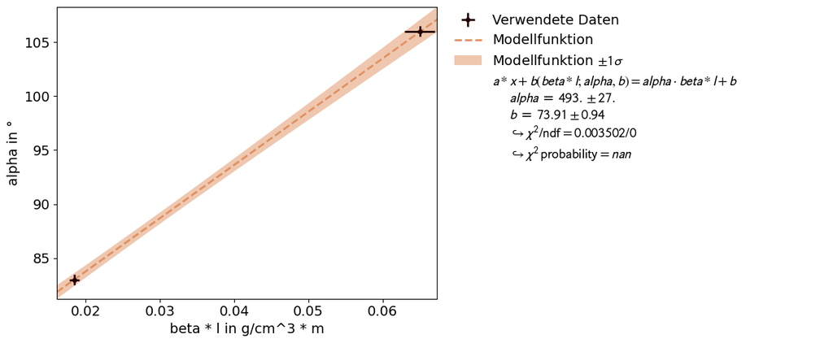

```python
alpha = unumpy.uarray(np.array([83,106]),np.full(2,0.5))
beta = unumpy.uarray(np.array([0.33,0.33]),np.full(2,0.01))
l =  unumpy.uarray([0.056,0.197],[0.001,0.001]) # in m Breite und Länge
hilfsgroesse = beta * l

xy_data = XYContainer(unumpy.nominal_values(hilfsgroesse),unumpy.nominal_values(alpha))
def linear(x,a=0,b=0):
    return a*x + b
line_fit=Fit(data=xy_data,model_function=linear)
line_fit.add_error(axis='x', err_val=unumpy.std_devs(hilfsgroesse))
line_fit.add_error(axis='y', err_val=unumpy.std_devs(alpha))
line_fit.do_fit()
line_fit.assign_parameter_latex_names(x='beta * l', a='alpha')
line_fit.assign_model_function_latex_name('a * x +b')
line_fit.assign_model_function_latex_expression('{a} \\cdot {x} + {b}')


line_fit.data_container.label = "Verwendete Daten"
line_fit.model_label = "Modellfunktion"

line_fit.data_container.axis_labels = ["beta * l in g/cm^3 * m", "alpha in °"]
plot = Plot(fit_objects= line_fit)
plot.plot()
plt.show()
```

Aus dem Fit erhalten wir einen spezifischen Drehwinkel von $\alpha_{spez} = 493 \pm 27\frac{1}{g/cm^3\cdot m}$. Es ist kein Literaturwert vorhanden, wodurch ein Vergleich nicht möglich ist. Durch die geringe Anzahl an Messwerten ist das Ergebnis nicht genau.